# Data Management and Exploratory Data Analysis in R

## Qual a utilidade dos modelos com Efeitos Mistos?

### Estruturas de dados aninhados

- Estudantes em escolas; Sujeitos em díades; Clientes em terapeutas…

### Pressuposto da independência das observações

- O valores de Y (VD) associados a \(X_i\) (VI) não são independentes
- Valores de \(Xi\) provavelmente correlacionados
- Estrutura de dependência implícita aos dados

## Tipos de estruturas de dados

### Dados agrupados

- Y (VD) medida uma vez por sujeito ou Unidade de Análise (UA)
- UA agrupadas em clusters (*Ex., peso de indivíduos de uma certa espécie em diferentes habitats*)

### Dados com medidas repetidas

- Y é medida mais do que uma vez por UA
- Fator de medida repetida pode ser o tempo ou outra condição experimental (*Ex., resposta neurológica em 3 áreas cerebrais diferentes de sujeitos em 2 tratamentos*)

### Dados longitudinais

- Y é medida vários vezes para cada sujeito (*Ex., competências de memória de crianças aos 4, 6, 8 e 10 anos*)

## Tipos de estruturas de dados

### Dados hierárquicos

[interactive chart not shown]

## Tipos de estruturas de dados

### Dados hierárquicos

- Nível 1: Medidas repetidas (*t*)
- Nível 2: Unidade de análise / Sujeitos (*i*)
- Nível 3: Cluster (*j*)

\[ \large y_{tij}=(\beta_{000} + b_{00j} + b_{0ij}) + (\beta_{100} + b_{10j} + b_{1ij})time_t + \nu_{tij} \]

## Fatores Fixos e Aleatórios

- Fatores Fixos (contexto clássico da ANOVA ou ANCOVA):
  - Variável de classificação cujos níveis são conhecidos e do interesse do investigador
  - **Efeito Fixo**: Número ou coeficiente de regressão, representando a relação entre VI e VD
- Fatores aleatórios
  - Variável de classificação com níveis aleatoriamente selecionados da população
  - Nem todos os níveis estarão representados na base de dados, no entanto, a intenção do investigador é generalizar à população
  - **Efeito Aleatório**: Variável aleatória que representa a variação face ao efeito fixo

## AGENDA

### Modelos multinível

- **Importação e análise exploratória dos dados**
- **GLM e regressão linear simples**
- **Regressão multinível**

## Importação e análise exploratória dos dados

## SchoolsData

```r
SchoolsData <- read.csv("I:\\My Drive\\FPCEUP\\AtividadeDocente\\MultilevelReg\\MLReg_data\\SchoolsData.csv")
```

## Estrutura geral Base de Dados (BD)

```r
str(SchoolsData)
```

```
## 'data.frame':    600 obs. of  7 variables:
##  $ Happiness    : num  86.2 80.3 80.4 81.5 78.5 ...
##  $ Friends      : num  12.74 8.87 10.73 11.27 10.81 ...
##  $ Quality      : num  3.14 3.46 4.44 4.54 5.32 ...
##  $ GPA          : num  2.74 1.47 2.08 2.94 3.33 ...
##  $ StudentID    : int  1 2 3 4 5 6 7 8 9 10 ...
##  $ SchoolID     : int  1 1 1 1 1 1 1 1 1 1 ...
##  $ SchoolContext: chr  "rich neighborhood" "rich neighborhood" "rich neighborhood" "rich neighborhood" ...
```

## Fatorização de variáveis

```r
SchoolsData$SchoolContext <- as.factor(SchoolsData$SchoolContext) # transformar a variável "SchoolContext" num fator
sapply(SchoolsData, class) # verificar a classe de todas as variáveis de SchoolsData
```

```
##     Happiness       Friends       Quality           GPA     StudentID
##     "numeric"     "numeric"     "numeric"     "numeric"     "integer"
##      SchoolID SchoolContext
##     "integer"      "factor"
```

```r
table(SchoolsData$SchoolContext)
```

```
##
## poor neighborhood rich neighborhood
##               480               120
```

## Estatística descritiva

```r
library(psych)
```

```r
psych::describe(SchoolsData[, -5:-7])
```

```
##           vars   n  mean    sd median trimmed   mad   min    max  range  skew
## Happiness    1 600 94.10 18.21  92.74   93.44 19.54 43.79 151.61 107.82  0.28
## Friends      2 600  5.96  2.81   5.43    5.80  2.46 -0.92  14.57  15.49  0.53
## Quality      3 600  4.13  1.69   4.28    4.15  2.21  1.03   6.95   5.92 -0.13
## GPA          4 600  2.50  0.89   2.52    2.50  1.16  1.00   4.00   3.00 -0.06
##           kurtosis   se
## Happiness    -0.21 0.74
## Friends       0.03 0.11
## Quality      -1.15 0.07
## GPA          -1.25 0.04
```

```r
psych::describeBy(SchoolsData[, -5:-6], group="SchoolContext")
```

[output not shown]

## Exploração gráfica dos dados

## Relação entre *Happiness* (VD) e *Friends* (VI)

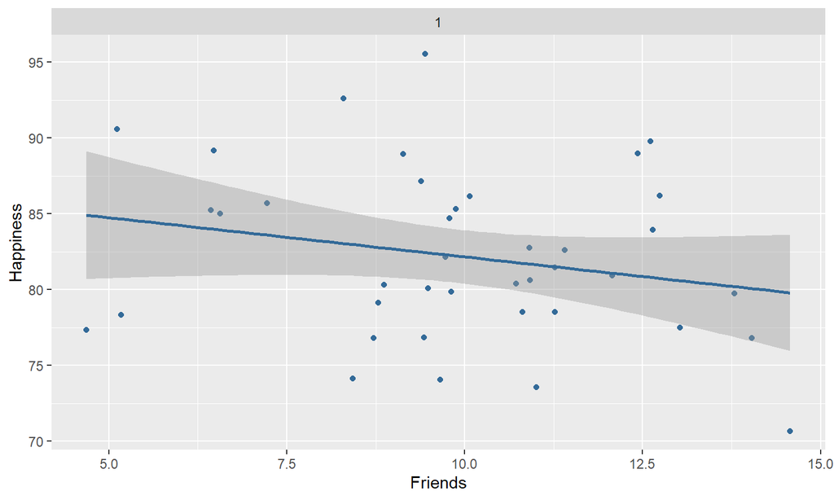

## Relação entre *Happiness* (VD) e *Quality* (VI)

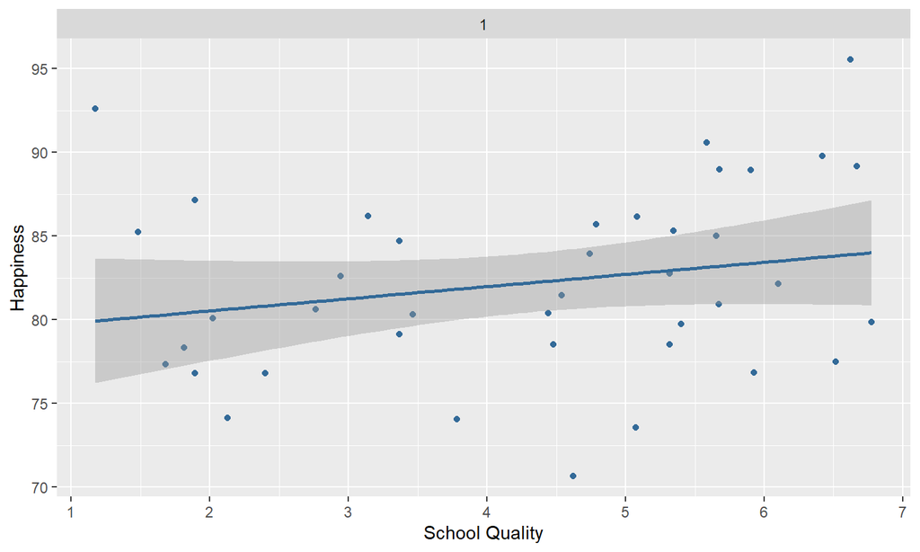

*O efeito positivo parece mais consistente nas escolas de baixo SES*

## Relação entre *GPA* (VI) e *Happiness* (VD)

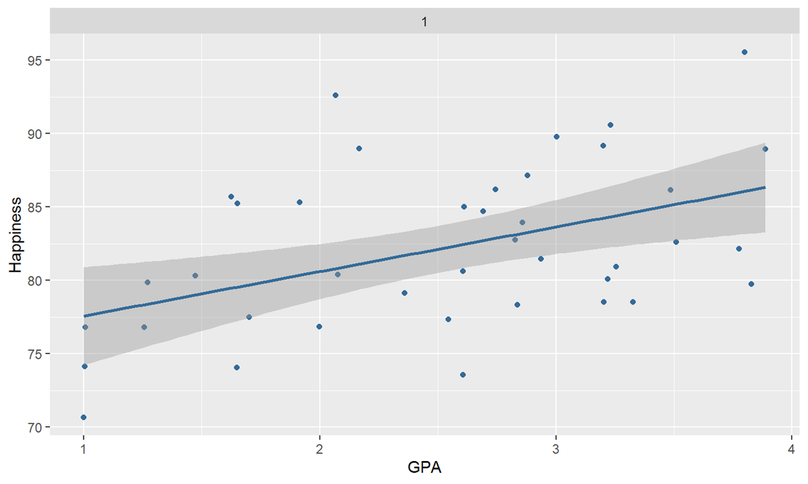

*Efeito mais evidente em escolas de elevado SES*

## Correlações para a amostra completa

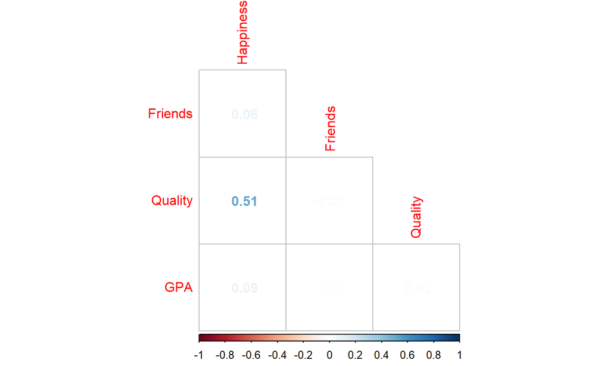

```r
corr.student  <-  cor(SchoolsData[,1:4])
corrplot::corrplot(corr.student, method = "number", diag = FALSE, type = "lower")
```

## Correlações para escolas de elevado SES

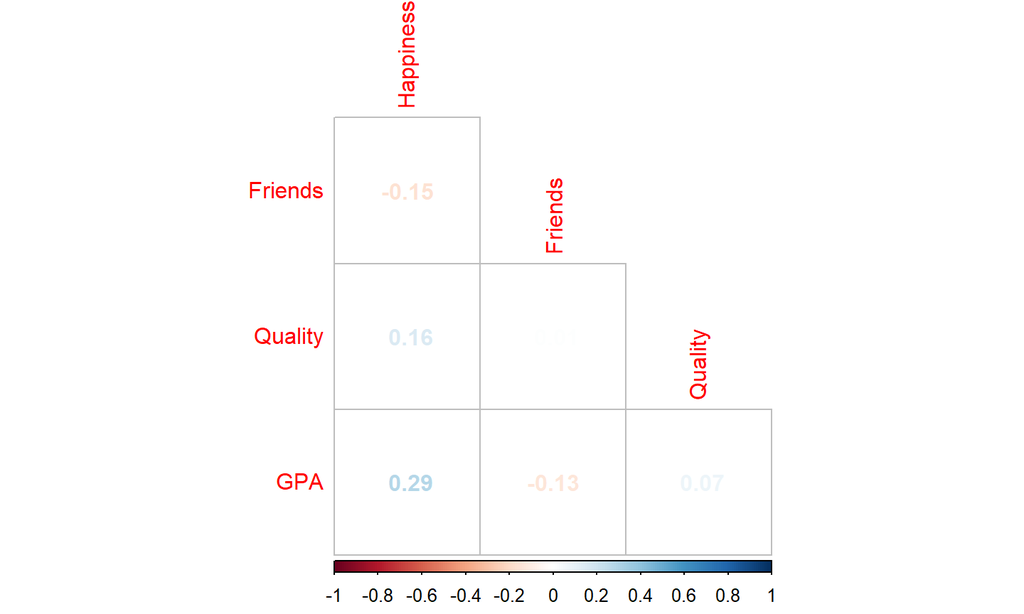

```r
SchoolsData_rich <- subset(SchoolsData, SchoolContext=="rich neighborhood")
corr.student_rich  <-  cor(SchoolsData_rich[,1:4])
corrplot(corr.student_rich, method = "number", diag = FALSE, type = "lower")
```

## Correlações para escolas de baixo SES

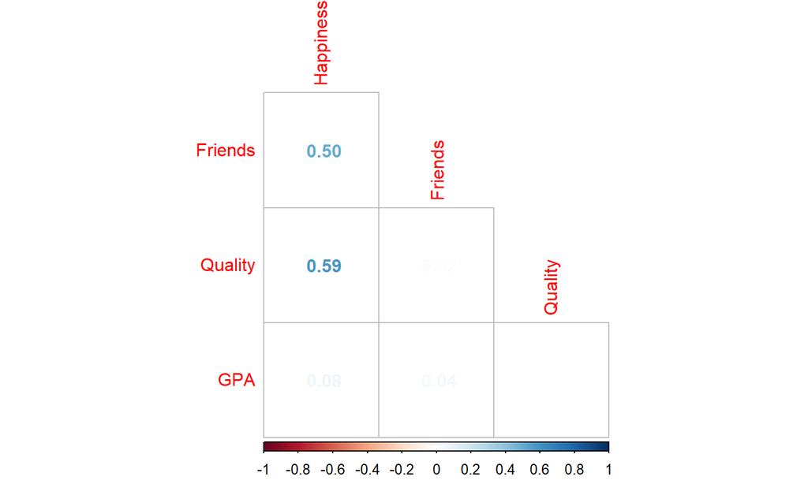

```r
SchoolsData_poor <- subset(SchoolsData, SchoolContext=="poor neighborhood")
corr.student_poor  <-  cor(SchoolsData_poor [,1:4])
corrplot(corr.student_poor, method = "number", diag = FALSE, type = "lower")
```

**CONCLUSÃO: As relações entre variáveis parecem variar em função do contexto escolar*

## GLM e Regressão linear Simples

## Modelo de regressão simples - SETUP

- Abordagem analítica ignora o facto dos dados estarem organizados de forma hierárquica
  - Vários estudantes partilham as mesmas escolas
- Centrar as variáveis à “grand mean” para facilitar a interpretação dos dados
  - Para isso, subtraímos a média da variável ao valores individuais
  - Usar função “scale()” com o argumento scale = FALSE.

```r
# ?scale
SchoolsData$Friends.C <- scale(SchoolsData$Friends, scale = FALSE)[,]
# equal to SchoolsData$Friends.C <- SchoolsData$Friends - mean(SchoolsData$Friends)
SchoolsData$Quality.C <- scale(SchoolsData$Quality, scale = FALSE)[,]
SchoolsData$GPA.C <- scale(SchoolsData$GPA, scale = FALSE)[,]
```

## Modelo de regressão simples

- Testar o modelo de regressão simples usando as variáveis centradas
  - O valor observado de zero corresponde a média da amostra

### O GLM expressa-se da seguinte forma:

\[\hat{Y_{i}} = \beta_0 + \beta_1X_{i1} + \beta_2X_{i2} + ... + \beta_pX_{ip}\] \[{Y_{i}} = \beta_0 + \beta_1X_{i1} + \beta_2X_{i2} + ... + \beta_pX_{ip} + \varepsilon_{i}\]

\[\varepsilon_{i} = {Y_{i}} - \hat{Y_{i}}\]

## Aplicação do GLM aos nossos dados

\[\hat{Happiness_{i}} = \beta_0 + \beta_1Friends.C_{i} + \beta_2Quality.C_{i} + \beta_3GPA.C_{i}\]

## Estimação OLS no R s

```r
Reg.Model <- lm(Happiness ~ Friends.C + Quality.C + GPA.C, data = SchoolsData)
summary(Reg.Model)$coefficients
```

```
##               Estimate Std. Error    t value     Pr(>|t|)
## (Intercept) 94.0997583  0.6337490 148.481124 0.000000e+00
## Friends.C    0.5962114  0.2256457   2.642246 8.452144e-03
## Quality.C    5.5237539  0.3753160  14.717610 4.765119e-42
## GPA.C        1.6131581  0.7134203   2.261161 2.410895e-02
```

*Será que obtemos os mesmos resultados em todas as escolas?*

## Avaliação dos pressupostos

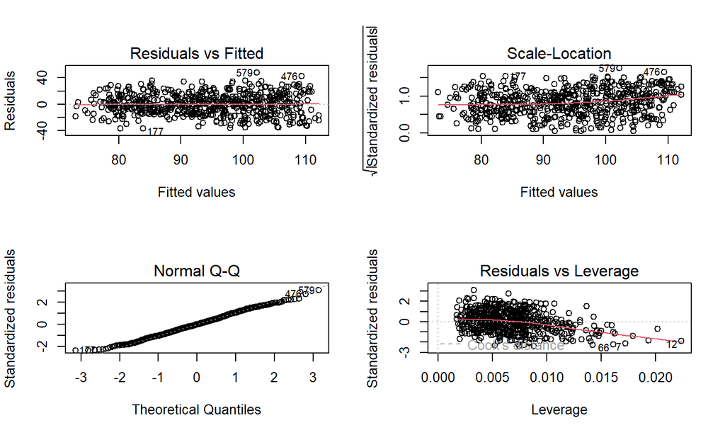

```r
layout(matrix(c(1,2,3,4),2,2))
plot(Reg.Model) # podemos avaliar visualmente a qualidade do modelo de regressão
```

## Avaliação dos pressupostos

- Linearidade (Residuals vs Fitted)  
  Se a VD estiver ligada de forma linear com as VI não existirá uma relação sistemática entre valores estimados e resíduos. No gráfico, os resíduos devem estar distribuídos homogeneamente ao longo da linha.
- Normalidade dos resíduos (Normal Q-Q)  
  Resíduos devem seguir uma linha reta, sobrepondo-se à linha tracejada no gráfico.
- Homocedasticidade (Scale-Location)  
  Em que medida os resíduos se distribuem de forma homogénea por valores de x. O gráfico deve apresentar uma linha horizontal com os pontos distribuídos de forma aparentemente aleatória.
- Outliers (Residuals vs Leverage)  
  Existem outliers? Estes casos surgirão fora da distância de Cook marcada a tracejado no gráfico.

## Estimação OLS do modelo para escolas de elevado SES

**A função subset () permite selecionar os casos pretendidos**

```r
Reg.Model_rich <- lm(Happiness ~ Friends.C + Quality.C + GPA.C,
                     data = subset(SchoolsData, SchoolContext=="rich neighborhood"))

summary(Reg.Model_rich)$coefficients
```

```
##               Estimate Std. Error   t value     Pr(>|t|)
## (Intercept) 85.0220649  1.5076176 56.394982 3.704374e-86
## Friends.C   -0.4582978  0.3413793 -1.342489 1.820589e-01
## Quality.C    0.7058204  0.4386589  1.609042 1.103255e-01
## GPA.C        2.4555035  0.8278183  2.966235 3.661329e-03
```

**NOTA: O efeito de Friends.C passa a negativo, enquanto que o de Quality.C é atenuado**

## Estimação OLS do modelo para escolas de baixo SES

```r
Reg.Model_poor <- lm(Happiness ~ Friends.C + Quality.C + GPA.C,
                     data = subset(SchoolsData, SchoolContext=="poor neighborhood"))
summary(Reg.Model_poor)$coefficients
```

```
##               Estimate Std. Error    t value     Pr(>|t|)
## (Intercept) 101.444935  0.6053951 167.568141 0.000000e+00
## Friends.C     4.838565  0.2717277  17.806668 9.862261e-55
## Quality.C     6.609611  0.3190524  20.716383 1.962475e-68
## GPA.C         1.065252  0.6091153   1.748852 8.096124e-02
```

```r
coef <- nlme::lmList(Happiness ~ Friends.C + Quality.C + GPA.C | SchoolID, data = SchoolsData)
```

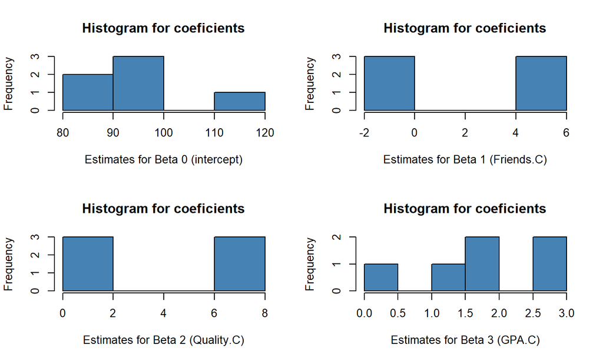

## Estimação OLS - GPA e Happiness

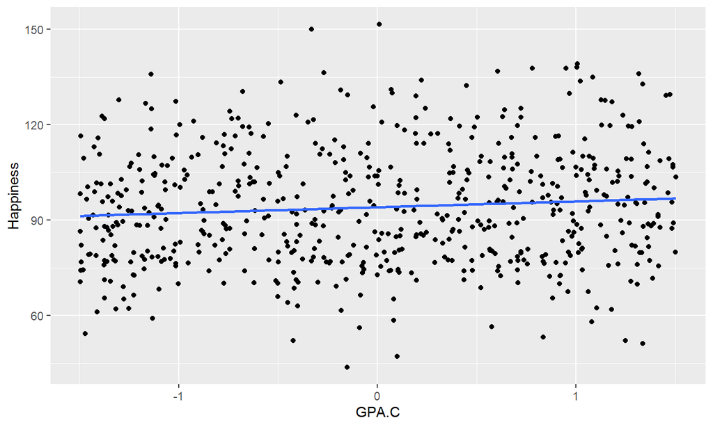

```r
ggplot(SchoolsData, aes(x=GPA.C, y=Happiness)) +
  geom_point() +
  geom_smooth(method=lm, se=FALSE, fullrange=TRUE)
```

## Estimação OLS - GPA e Happiness

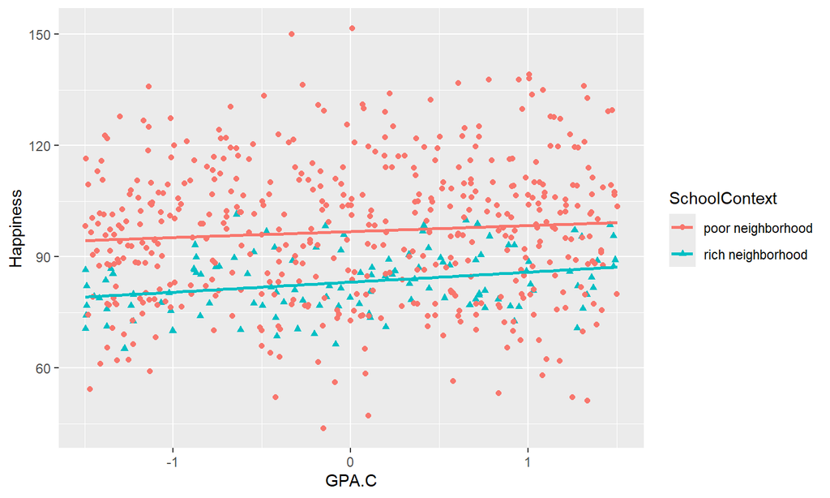

```r
ggplot(SchoolsData, aes(x=GPA.C, y=Happiness, shape=SchoolContext, color=SchoolContext)) +
  geom_point() +
  geom_smooth(method=lm, se=FALSE, fullrange=TRUE)
```

## Modelo de regressão simples - conclusão

### Os resultados da regressão OLS não consideram a estrutura aninhada dos dados

### Conclusões potencialmente erradas:

- Pressuposto da dependência dos dados é violado
- Crianças na mesma escola terão scores mais correlacionados
- A inflação das correlações dentro do grupo/escola (within-group correlation)
  - Estimação inapropriada dos erros das estimativas
  - Aumento da probabilidade do **erro tipo 1**

## Regressão multinível

## Regressão simples Vs. multinível

- Os modelos multinível distinguem variância dentro (“within-group”) de variância entre grupos (“between-group”)
- Na regressão simples este dois tipos de variâncias são combinados num único **parâmetro** (\(\varepsilon_{i}\))

\[{y_{i}} = \beta_{0} + \beta_{1}x_{i} + \varepsilon_{i}\] LEGENDA:  
*i* = indivíduos; \({y_{i}}\) = score do indivíduo *i* na variável *y*;  
\(x_{i}\) = variável independente; \(\beta_{0}\) = intercept, valor de \({y}\) quando \(x\) toma o zero;  
\(\beta_{1i}\) = a slope que define a relação entre \(x\) e \({y}\);  
\(\varepsilon_{i}\) = resíduo aleatório associado aos score do indivíduo *i* (i.e., \({Y_{i}} - \hat{Y_{i}}\));

## Efeitos “within-group” e “between-group”

\[{y_{i}} = \beta_{0} + \beta_{1}x_{i} + \varepsilon_{i}\]

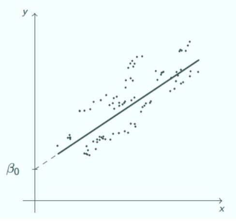

## Efeitos “within-group” e “between-group”

### Quando as observações não são independentes, **poderão** existir nos diferentes grupos:

- diferentes médias (intercepts, x=0)
- diferentes relações entre x e y (slope)
  - *O modelo de regressão simples apenas será suficiente (i.e., correto) quando não existe efeito do grupo (“between-group”)*

**Então, como podemos estimar o efeito do grupo?**

## Modelo Nulo e ICC (Intraclass Correlation)

### Será realmente necessário adotar uma abordagem multinível?

- Testar o modelo multinível mais simples - **MODELO NULO**
  - Avalia o efeito médio do contexto sobre a VD (i.e., *Happiness*)
  - Modelo sem VI’s

*Nível 1*

\[{y_{ij}} = \beta_{0j} + \varepsilon_{ij}\] *Nível 2*

\[\beta_{0j} = \gamma_{00} + U_{0j}\]

## Modelo nulo - decomposição da variância

- O modelo nulo permite apenas estimar variâncias *between-* e *within-group*

\[{y_{ij}} = \gamma_{00} + U_{0j} + \varepsilon_{ij}\] LEGENDA:  
*i* = unidade de nível 1; *j* = unidade de nível 2;  
\({y_{ij}}\) = score do indivíduo *i* no grupo *j* na variável *y*;  
\(\gamma_{00}\) = intercept médio constante para todos indivíduos *i* (*fixed effect*);  
\(U_{0j}\) = efeito específico do grupo *j* no intercept (*random effect*) OU variância devida ao grupo (*between-group*);  
\(\varepsilon_{ij}\) = resíduo aleatório associado aos score do indivíduo *i* (*within-group*).

## Modelo nulo - decomposição da variância

\[{y_{ij}} = \gamma_{00} + U_{0j} + \varepsilon_{ij}\]

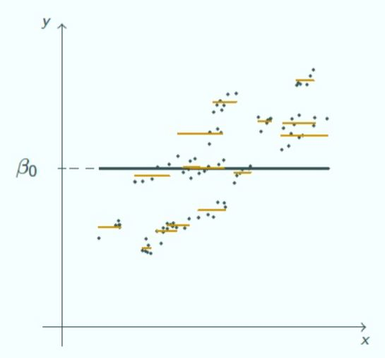

## O Intraclass Correlation (ICC)

### Representa efeito do cluster nos scores da VD

- Medida da quantidade de variância da VD explicada pelo nível 2 do modelo
- Correlação média nos scores da VD entre indivíduos no mesmo grupo
- ICC diferente de 0 justifica a adoção de modelos multinível?

\[\rho = \frac{\tau^{2}}{\tau^{2} + \sigma^{2}}\] LEGENDA:  
\(\rho\) = ICC; \(\tau^{2}\) = variância *between-group* (\(U_{0j}\) na equação); \(\sigma^{2}\) = variância *within-group* (\(\varepsilon_{ij}\) na equação).

## Cálculo do ICC no R

### Recorremos ao pacote lme4 no R para estimar modelos multinível no R

```r
library(lme4) # se necessário: install.packages("lme4")
head(SchoolsData, 3)
```

```
##   Happiness   Friends  Quality      GPA StudentID SchoolID     SchoolContext
## 1  86.19639 12.741917 3.140332 2.744812         1        1 rich neighborhood
## 2  80.30396  8.870604 3.463811 1.473716         2        1 rich neighborhood
## 3  80.38805 10.726257 4.440855 2.077085         3        1 rich neighborhood
##   Friends.C  Quality.C      GPA.C
## 1  6.779751 -0.9906700  0.2478625
## 2  2.908438 -0.6671913 -1.0232338
## 3  4.764091  0.3098534 -0.4198646
```

## Cálculo do ICC no R

```r
Null <- lmer(Happiness ~ 1 # define “Happinesss” em função do intercept (fixed effect)
             + (1|SchoolID), # e que cada escola tem o seu intercept (random effect)
             data=SchoolsData) # base de dados
```

Fórmula do modelo:  
- VD antes do operador “~”;  
- VI após “~”;  
- Efeitos fixos (fixed-effects) imediatamente após “~”;  
- **1** representa o intercept;  
- Efeitos aleatórios (random-effects) entre parêntesis;  
- O modelo dos random effects é definido antes do operador “|”;  
- A variável que representa o cluster (nível 2) na BD surge depois de “|”;  
- O argumento “data” identifica a base de dados.

## Cálculo do ICC no R

```r
summary(Null)
```

```
## Linear mixed model fit by REML. t-tests use Satterthwaite's method [
## lmerModLmerTest]
## Formula: Happiness ~ 1 + (1 | SchoolID)
##    Data: SchoolsData
##
## REML criterion at convergence: 5070.4
##
## Scaled residuals:
##      Min       1Q   Median       3Q      Max
## -2.80824 -0.61011 -0.00664  0.59575  2.88781
##
## Random effects:
##  Groups   Name        Variance Std.Dev.
##  SchoolID (Intercept)  94.7     9.731
##  Residual             267.3    16.348
## Number of obs: 600, groups:  SchoolID, 6
##
## Fixed effects:
##             Estimate Std. Error     df t value Pr(>|t|)
## (Intercept)   90.179      4.058  4.999   22.22 3.44e-06 ***
## ---
## Signif. codes:  0 '***' 0.001 '**' 0.01 '*' 0.05 '.' 0.1 ' ' 1
```

## Cálculo do ICC no R

O sumário do modelo nulo permite extrair as duas componentes de variância: * *between-group* (\(\tau^{2}\)) e *within-group* (\(\sigma^{2}\))

Podemos usar estes valores para calcular o ICC

## Cálculo do ICC no R

A função VarCorr() permite extrair as componentes de variância estimadas pelo modelo

```r
vc <- VarCorr(Null)
```

Utilizamos a função print() para visualizar essas componentes de variância

```r
print(vc, comp=c("Variance", "Std.Dev"))
```

```
##  Groups   Name        Variance Std.Dev.
##  SchoolID (Intercept)  94.701   9.7314
##  Residual             267.263  16.3482
```

## Cálculo do ICC no R

Criamos agora um objeto de dados apenas com as variâncias…

```r
vc <- as.data.frame(vc)[,c("grp", "vcov")]
```

…e calculamos o ICC:

```r
vc[1,2]
```

```
## [1] 94.70073
```

```r
vc[,2]
```

```
## [1]  94.70073 267.26342
```

```r
(ICC <- vc[1,2]/sum(vc[,2]))
```

```
## [1] 0.2616301
```

## Cálculo do ICC no R

Podemos guardar numa função para futura utilização

```r
ICC_user <- function(nome.modelo) {
  vc <- VarCorr(nome.modelo)
  vc <- print(vc, comp=c("Variance", "Std.Dev"))
  vc <- as.data.frame(vc)[,c("grp", "vcov")]
  ICC <- vc[1,2]/sum(vc[,2])
  return(c(ICC = ICC))
}
```

```r
ICC_user(Null)
```

```
##  Groups   Name        Variance Std.Dev.
##  SchoolID (Intercept)  94.701   9.7314
##  Residual             267.263  16.3482
```

```
##       ICC
## 0.2616301
```

## Cálculo do ICC no R

Ainda um pouco mais simples com a função *performance::icc()*

```r
# se necesssário, install.packages("performance")
library(performance)
icc(Null)
```

```
## # Intraclass Correlation Coefficient
##
##     Adjusted ICC: 0.262
##   Unadjusted ICC: 0.262
```

## Quão baixo deve ser o ICC para se “evitar” a abordagem multinível?

Mesmo ICC’s baixos podem levar a estimativas enviesadas

### O efeito do design (DEFF; Kish, 1965)

- Rácio da variância de grupo observada (\(\rho\)) com a variância esperada numa amostra independente (não agrupada)

\[DEFF = 1 + (nc - 1) * \rho\] LEGENDA: \(\rho\) = ICC; \(nc\) = tamanho médio do cluster;

**DEFF = 1 indica ausência de efeito de cluster**  
* Assim **\(\rho\) = 0** OU **\(nc\) = 1** são necessários para que DEFF = 1  
* Logo, não é apenas o ICC que deve ser considerado  
* DEFF < 2 visto como valor de referência (Lai & Kwok, 2015)

## Random Intercept Model com preditor de nível 1

\[y_{i} = \gamma_{00} + \beta_{1j}x + U_{0j} + \varepsilon_{i}\]

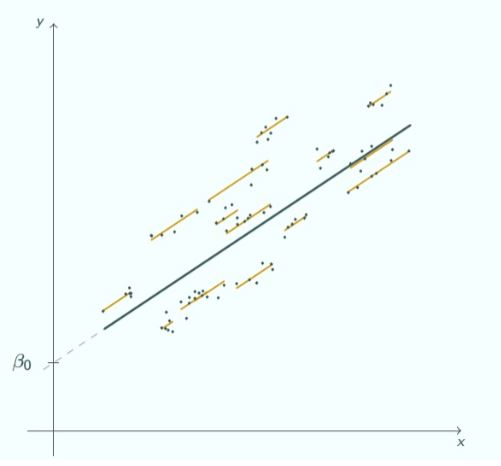

## Random Intercept Model com preditor de nível 1

Este modelo consiste numa extensão do modelo nulo, incluindo um preditor de nível 1 (i.e., estudante)  
- Especifica o efeito de *GPA* (fixed effect) sobre *Happiness* e considera-se a variação do intercept ao nível da escola (random effect)

*Este modelo pode ser representado pela seguinte equação:*

\[Happiness_{i} = \gamma_{00} + \beta_{1j}GPA + U_{0j} + \varepsilon_{i}\] **Fixed effects:**  
\(\gamma_{00}\) = intercept do modelo  
\(\beta_{1j}GPA\) = Efeito médio de GPA sobre happiness  
**Random effects:**  
\(U_{0j}\) = variância específica do grupo  
\(\varepsilon_{i}\) = variáncia individual

## Random Intercept Model com preditor de nível 1

Ajustamento do modelo no R

```r
Model.1 <- lmer(Happiness ~ GPA.C + (1 | SchoolID), data=SchoolsData)
```

A sintaxe especifica que:

- O score de “Happiness” é predito pela variável “GPA” (fixed effect)
- A parte aleatória do modelo (random intercept) e a identificação do cluster (dentro de parêntesis)
- “(1 | SchoolID)” indica que apenas iremos considerar a variação do intercept (random intercept model)

## Random Intercept Model com preditor de nível 1

O sumário do modelo apresenta os efeitos fixos e desvios padrão (efeitos aleatórios).

```r
summary(Model.1)
```

```
## Linear mixed model fit by REML. t-tests use Satterthwaite's method [
## lmerModLmerTest]
## Formula: Happiness ~ GPA.C + (1 | SchoolID)
##    Data: SchoolsData
##
## REML criterion at convergence: 5063.4
##
## Scaled residuals:
##      Min       1Q   Median       3Q      Max
## -2.89226 -0.61035  0.01524  0.58202  2.89753
##
## Random effects:
##  Groups   Name        Variance Std.Dev.
##  SchoolID (Intercept)  94.72    9.732
##  Residual             265.16   16.284
## Number of obs: 600, groups:  SchoolID, 6
##
## Fixed effects:
##             Estimate Std. Error       df t value Pr(>|t|)
## (Intercept)  90.1799     4.0579   4.9978   22.22 3.44e-06 ***
## GPA.C         1.7894     0.7486 593.0384    2.39   0.0171 *
## ---
## Signif. codes:  0 '***' 0.001 '**' 0.01 '*' 0.05 '.' 0.1 ' ' 1
##
## Correlation of Fixed Effects:
##       (Intr)
## GPA.C 0.000
```

## Efeitos fixos

```r
summary(Model.1)$coefficients
```

```
##              Estimate Std. Error        df   t value     Pr(>|t|)
## (Intercept) 90.179930  4.0579373   4.99782 22.223096 3.441119e-06
## GPA.C        1.789382  0.7485788 593.03841  2.390372 1.714235e-02
```

## Efeitos aleatórios

```r
summary(Model.1)$varcor
```

```
##  Groups   Name        Std.Dev.
##  SchoolID (Intercept)  9.7324
##  Residual             16.2837
```

## Random Intercept Model com preditor de nível 1

Podemos ainda comparar o ajustamento do modelo 1 relativamente ao modelo nulo, apenas com o intercept aleatório.

```r
anova(Null, Model.1)
```

```
## refitting model(s) with ML (instead of REML)
```

```
## Data: SchoolsData
## Models:
## Null: Happiness ~ 1 + (1 | SchoolID)
## Model.1: Happiness ~ GPA.C + (1 | SchoolID)
##         npar    AIC    BIC  logLik deviance  Chisq Df Pr(>Chisq)
## Null       3 5080.9 5094.1 -2537.4   5074.9
## Model.1    4 5077.2 5094.8 -2534.6   5069.2 5.6963  1      0.017 *
## ---
## Signif. codes:  0 '***' 0.001 '**' 0.01 '*' 0.05 '.' 0.1 ' ' 1
```

## Pesos de regressão standardizados

```r
# library(effectsize)
standardize(Model.1) # pré
```

```
## Linear mixed model fit by REML ['lmerModLmerTest']
## Formula: Happiness ~ GPA.C + (1 | SchoolID)
##    Data: data_std
## REML criterion at convergence: 1592.617
## Random effects:
##  Groups   Name        Std.Dev.
##  SchoolID (Intercept) 0.5343
##  Residual             0.8940
## Number of obs: 600, groups:  SchoolID, 6
## Fixed Effects:
## (Intercept)        GPA.C
##    -0.21521      0.08736
```

```r
standardize_parameters(Model.1) # pós
```

```
## # Standardization method: refit
##
## Parameter   | Std. Coef. |        95% CI
## ----------------------------------------
## (Intercept) |      -0.22 | [-0.65, 0.22]
## GPA.C       |       0.09 | [ 0.02, 0.16]
```

## Random Intercept Model com preditor de nível 1

Finalmente, calculamos a variância explicada (r2) pelo modelo através da função r.squaredGLMM() do pacote MuMIn

```r
# install.packages("MuMIn")
library(MuMIn)
r.squaredGLMM(Model.1, null=Null)
```

```
##              R2m       R2c
## [1,] 0.006986497 0.2683479
```

*NOTA: R2m consiste na variância explicada apenas pelos fixed effects, enquanto que o indicador R2c representa a variância explicada pela totalidade do modelo, considerando tanto os fixed como os random effects*

## Duas notas

- **Cálculo do valores de *p* (significância)**
- **Métodos de estimação**

## Os valores de *p* (significância)

- Existem vários métodos para calcular os valores de *p* em modelos multinível
  - Diferentes programas estatísticos adotam diferentes métodos:
    - HLM recurso à distribuição t
    - SAS e SPSS utilizam a aproximação de Satterthwaite
    - Aproximação Kenward-Roger disponível em algumas aplicações, nomeadamente no R

POR NORMA, estes métodos produzem resultados muito aproximados

## Os valores de *p* (significância)

- No R, é necessário recorrer ao pacote lmerTest para obter os valores de p
  - Este pacote permite, através do argumento ddf, utilizar vários métodos para calcular os valores de p

```r
# se necessário install.packages("lmerTest")
library(lmerTest)
# ?lmerTest::lmer
summary(Model.1, ddf = "lme4")
summary(Model.1, ddf = "Satterthwaite")
summary(Model.1, ddf = "Kenward-Roger")
```

## Métodos de estimação

Ao contrário da regressão tradicional o método de estimação por OLS não é o mais adequado em modelos multinível  
As abordagens mais usuais são:  
- Maximum Likelihood Estimation (MLE)  
- Restricted Maximum Likelihood (REML)

Estes dois métodos diferem na fórmula de calcular os graus de liberdade para estimação das variâncias  
- Ao contrário do MLE, o REML tem em conta o número de parâmetros estimados pelo modelo quando determina os graus de liberdade  
- O MLE não tem isto em conta, podendo resultar na subestimação das variâncias

## Random Intercept Model com preditores (L1 e L2)

Apresentamos de seguida um modelo com os fixed effects de variáveis do nível 1 (aluno) e 2 (escola)

Começamos por criar e incluir na nossa base de dados um preditor de nível 2 (“SchoolAveQuality”)  
- Qualidade média da escola percecionada pelos seus alunos

```r
head(SchoolsData,3)
```

```
##   Happiness   Friends  Quality      GPA StudentID SchoolID     SchoolContext
## 1  86.19639 12.741917 3.140332 2.744812         1        1 rich neighborhood
## 2  80.30396  8.870604 3.463811 1.473716         2        1 rich neighborhood
## 3  80.38805 10.726257 4.440855 2.077085         3        1 rich neighborhood
##   Friends.C  Quality.C      GPA.C
## 1  6.779751 -0.9906700  0.2478625
## 2  2.908438 -0.6671913 -1.0232338
## 3  4.764091  0.3098534 -0.4198646
```

```r
AveQual <- with(SchoolsData, tapply(Quality, SchoolID, mean))
SchoolsData$SchoolAveQuality <- AveQual[SchoolsData$SchoolID]
```

## Random Intercept Model com preditores (L1 e L2)

- 3 preditores de nível 1: GPA, número de amigos e qualidade percecionada individualmente pelos alunos
- 1 preditor de nível 2, qualidade média da escola

Serão apenas estimados os fixed effects destes preditores

```r
Model.2 <- lmer(Happiness ~ GPA.C + Friends.C + Quality.C + SchoolAveQuality + (1 | SchoolID), data=SchoolsData)
```

Tal como os preditores de nível 1, o preditor de nível 2, “SchoolAveQuality” é incluído como fixed effect, não sendo incluída qualquer componente aleatória (random effect). Apresenta por isso um efeito fixo (médio) que é comum a todas as escolas.

## Random Intercept Model com preditores (L1 e L2)

```r
summary(Model.2, ddf = "Satterthwaite")
```

```r
summary(Model.2, ddf = "Satterthwaite")$coefficients
```

```
##                    Estimate  Std. Error         df    t value     Pr(>|t|)
## (Intercept)      121.776924 197.5660153   3.979437  0.6163860 5.711522e-01
## GPA.C              1.527301   0.4991908 590.979695  3.0595527 2.317129e-03
## Friends.C          3.556823   0.2191486 594.336797 16.2301875 2.638292e-49
## Quality.C          5.804147   0.2635530 590.978112 22.0226887 6.202041e-79
## SchoolAveQuality  -8.956257  48.0444305   3.978622 -0.1864161 8.612373e-01
```

- Todas as variáveis de nível 1 apresentam efeitos significativos sobre “Happiness”
- Pelo contrário, a qualidade média das escolas (preditor de nível 2) não tem um efeito significativo sobre a VD

## Random Intercept Model com preditores (L1 e L2)

### Incremento na variância explicada face ao modelo 1

```r
# ?r.squaredGLMM
r.squaredGLMM(Model.2, null=Null)
```

```
##            R2m       R2c
## [1,] 0.2753162 0.8360867
```

```r
r.squaredGLMM(Model.1, null=Null)
```

```
##              R2m       R2c
## [1,] 0.006986497 0.2683479
```

## Random Intercept Model com preditores (L1 e L2)

### Comparação do ajustamento dos modelos

```r
anova(Null, Model.1, Model.2)
```

```
## refitting model(s) with ML (instead of REML)
```

```
## Data: SchoolsData
## Models:
## Null: Happiness ~ 1 + (1 | SchoolID)
## Model.1: Happiness ~ GPA.C + (1 | SchoolID)
## Model.2: Happiness ~ GPA.C + Friends.C + Quality.C + SchoolAveQuality + (1 | SchoolID)
##         npar    AIC    BIC  logLik deviance    Chisq Df Pr(>Chisq)
## Null       3 5080.9 5094.1 -2537.4   5074.9
## Model.1    4 5077.2 5094.8 -2534.6   5069.2   5.6963  1      0.017 *
## Model.2    7 4606.7 4637.5 -2296.3   4592.7 476.5137  3     <2e-16 ***
## ---
## Signif. codes:  0 '***' 0.001 '**' 0.01 '*' 0.05 '.' 0.1 ' ' 1
```

## Random Intercept and slope Model

Este modelo acrescenta uma slope aleatória ao modelo anterior com intercept aleatório  
- considera-se a variação intercept (random effect) associado à escola  
- considera-se a variação no efeito entre as VI’s e VD associado à escola

Nivel 1: \[y_{ij} = \beta_{0j} + \beta_{1j}x + \varepsilon_{ij}\]

Nivel 2: \[\beta_{0j} = \gamma_{00} + U_{0j}\]

\[\beta_{1j} = \gamma_{10}x_{ij} + U_{1j}x_{ij}\]

## Random Intercept and slope Model

### Equação completa do modelo

\[y_{ij} = \gamma_{00} + \gamma_{10}x_{ij} + U_{0j} + U_{1j}x_{ij} + \varepsilon_{ij}\] LEGENDA:  
*i* = unidade de nível 1; *j* = unidade de nível 2;  
\({y_{ij}}\) = score do indivíduo *i* no grupo *j* na variável *y*; \(\gamma_{00}\) = intercept médio, constante para todos indivíduos *i* (*fixed effect*);  
\(\gamma_{10}x_{ij}\) = slope média, constante para todos indivíduos *i* (*fixed effect*);  
\(U_{0j}\) = efeito específico do grupo *j* no intercept (*random effect*); \(U_{1j}x_{ij}\) = efeito específico do grupo *j* na slope (*random effect*); \(\varepsilon_{ij}\) = resíduo aleatório associado aos score do indivíduo *i* (*within-group*).

## Random Intercept and slope Model

\[y_{ij} = \gamma_{00} + \gamma_{10}x_{ij} + U_{0j} + U_{1j}x_{ij} + \varepsilon_{ij}\]

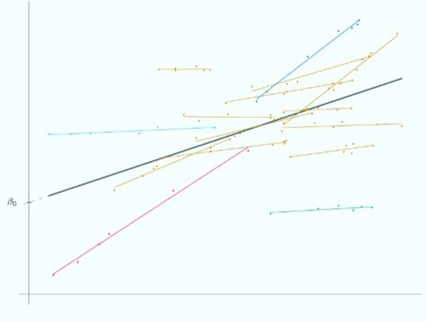

## Random Intercept and slope Model

O modelo seguinte, para além do intercept, especifica como aleatório o efeito de *Friends* em *Happiness*  
- Assume que a relação entre número de amigos e felicidade pode mudar de escola para escola  
- Mantemos os efeitos de GPA e Quality como fixed effects

```r
Model.3 <- lmer(Happiness ~ GPA.C + Friends.C + Quality.C +
                  (1 + Friends.C | SchoolID), data = SchoolsData)
```

```r
summary(Model.3)
```

## Efeitos fixos

```r
summary(Model.3)$coefficients
```

```
##              Estimate Std. Error         df   t value     Pr(>|t|)
## (Intercept) 93.898301  4.5813093   4.916492 20.495953 5.956612e-06
## GPA.C        1.245179  0.4492734 587.364573  2.771539 5.755993e-03
## Friends.C    2.012856  1.2820987   4.983551  1.569970 1.774093e-01
## Quality.C    5.876966  0.2372871 588.263226 24.767327 2.613503e-93
```

- Os resultados sugerem que o número de amigos não tem um efeito significativo sobre a felicidade quando controlado o efeito de escola
  - i.e., não existe um efeito significativo entre “Friends” e “Happiness” que possa ser generalizado a todas escolas

## Efeitos aleatórios

```r
summary(Model.3)$varcor
```

```
##  Groups   Name        Std.Dev. Corr
##  SchoolID (Intercept) 10.9931
##           Friends.C    3.0874  0.649
##  Residual              9.7327
```

- Cada escola tem o seu intercept e o efeito do número de amigos também pode variar em função da escola
- Os resultados permitem descrever as estimativas para a variância do intercept (random), variância da slope (random), bem como as correlações entre estas random intercept e slope

## Random Intercept and slope Model

Podemos acrescentar ao modelo os random effects para as restantes variáveis de nível 1.

```r
Model.4 <- lmer(Happiness ~  GPA.C + Quality.C + Friends.C +
                  (1 + GPA.C + Quality.C + Friends.C | SchoolID), data = SchoolsData)
```

```
## boundary (singular) fit: see help('isSingular')
```

Agora, a cada uma das escolas está associado um intercept bem como diferentes slopes para “GPA”, “Quality” e “Friends”.

```r
summary(Model.4)
```

## Random Intercept and slope Model

A função ranova() pode-nos ajudar a melhorar o modelo  
Permite verificar o efeito da retirada de cada um dos random effects do modelo

```r
# library(lmerTest)
ranova(Model.4)
```

```
## boundary (singular) fit: see help('isSingular')
## boundary (singular) fit: see help('isSingular')
```

```
## ANOVA-like table for random-effects: Single term deletions
##
## Model:
## Happiness ~ GPA.C + Quality.C + Friends.C + (1 + GPA.C + Quality.C + Friends.C | SchoolID)
##                                                             npar  logLik    AIC
## <none>                                                        15 -2185.4 4400.8
## GPA.C in (1 + GPA.C + Quality.C + Friends.C | SchoolID)       11 -2185.5 4392.9
## Quality.C in (1 + GPA.C + Quality.C + Friends.C | SchoolID)   11 -2234.8 4491.5
## Friends.C in (1 + GPA.C + Quality.C + Friends.C | SchoolID)   11 -2254.2 4530.4
##                                                                 LRT Df
## <none>
## GPA.C in (1 + GPA.C + Quality.C + Friends.C | SchoolID)       0.073  4
## Quality.C in (1 + GPA.C + Quality.C + Friends.C | SchoolID)  98.681  4
## Friends.C in (1 + GPA.C + Quality.C + Friends.C | SchoolID) 137.555  4
##                                                             Pr(>Chisq)
## <none>
## GPA.C in (1 + GPA.C + Quality.C + Friends.C | SchoolID)         0.9994
## Quality.C in (1 + GPA.C + Quality.C + Friends.C | SchoolID)     <2e-16 ***
## Friends.C in (1 + GPA.C + Quality.C + Friends.C | SchoolID)     <2e-16 ***
## ---
## Signif. codes:  0 '***' 0.001 '**' 0.01 '*' 0.05 '.' 0.1 ' ' 1
```

## Random Intercept and slope Model

```r
Model.5 <- lmer(Happiness ~ GPA.C + Quality.C + Friends.C +
                  (1 + Friends.C | SchoolID), data = SchoolsData)
```

```r
summary(Model.5)
```

## Conclusão

## OLS Vs. Multinível

Os resultados anteriores salientam a importância de uma abordagem multinível para lidar com dados agrupados

- Isto fica claro se compararmos os resultados com os resultados obtidos pela regressão OLS

```r
Model2_SR <- lm(Happiness ~ Friends.C, data = SchoolsData)
summary(Model2_SR)$coefficients
```

```
##               Estimate Std. Error    t value   Pr(>|t|)
## (Intercept) 94.0997583  0.7417524 126.861415 0.00000000
## Friends.C    0.5252129  0.2640365   1.989168 0.04713788
```

## OLS Vs. Multinível

```r
Model.8 <- lmer(Happiness ~ Friends.C +
                  (1 + Friends.C | SchoolID), data = SchoolsData)
summary(Model.8)$coefficients
```

```
##              Estimate Std. Error       df   t value     Pr(>|t|)
## (Intercept) 93.895268   4.245125 4.811479 22.118373 5.021080e-06
## Friends.C    1.893902   1.311675 4.770236  1.443881 2.110834e-01
```

## OLS Vs. Multinível

- Como sabemos, o efeito do número de amigos na felicidade varia em função das características das escolas

```r
Model.8 <- lmer(Happiness ~ Friends.C + SchoolContext + Friends.C*SchoolContext +
                  (1 | SchoolID), data = SchoolsData)
```

```r
summary(Model.8)
```

## OLS Vs. Multinível

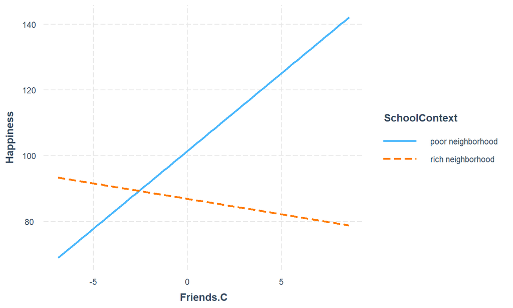

```r
library(interactions)
probe_interaction(Model.8, Friends.C, SchoolContext)$interactplot
```

## Laboratório

## Joop Hox, Mirjam Moerbeek, Rens van de Schoot

[Multilevel Analysis: Techniques and Applications](https://www.taylorfrancis.com/books/mono/10.4324/9781315650982/multilevel-analysis-joop-hox-mirjam-moerbeek-rens-van-de-schoot)

[figure not shown]

## Proposta de trabalho

- Selecionar uma das bases de dados de: Multilevel Analysis: Techniques and Applications

### Para a base de dados selecionada:

1. importar os dados para R e fazer ajustes necessários;
2. análise exploratória e visualização dos dados;
3. definir uma questão de investigação tendo em conta dos dados disponíveis;
4. selecionar e aplicar a melhor estratégia de modelação para responder à questão de investigação.